# case_study_RT_accuracy

Shiva Upadhye

2023-06-13

## Data cleaning

### 1. Examine RT distribution

Examine the distribution of RT (subjMean_BlockRT) across subjects. Does it make sense?

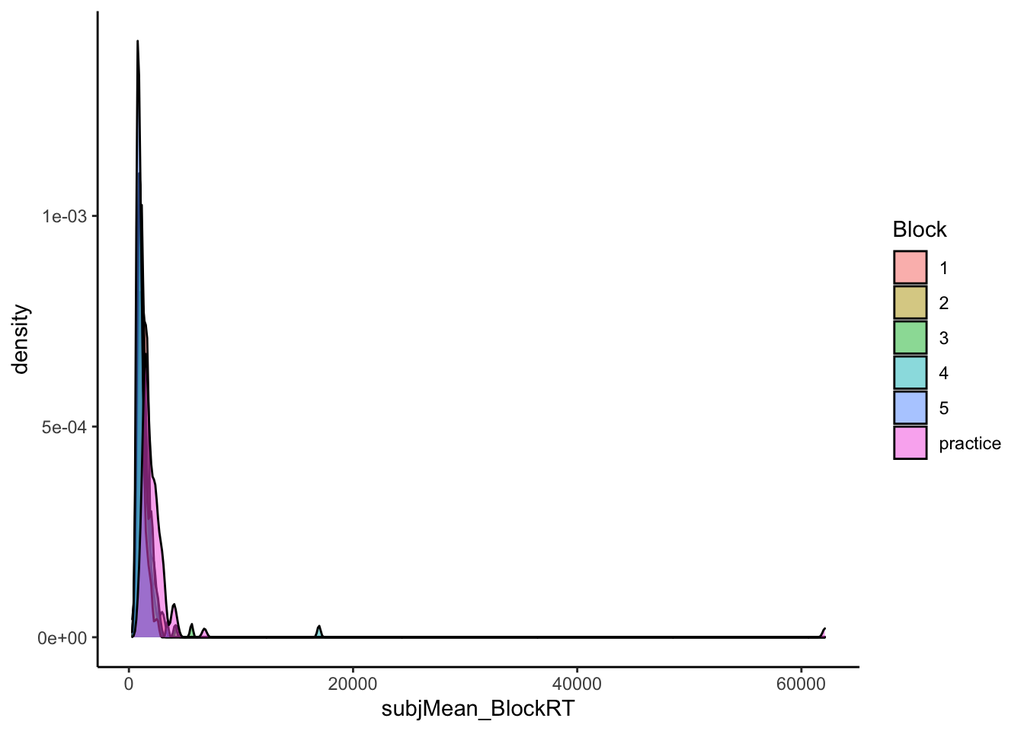

## 2. Data exclusion

Describe the procedure you take to exclude outliers (subjects, trials, etc.).

### Exclusion by subject

e.g., We want to identify and remove subjects who consistently registered slow response times because they did not perform the task faithfully (e.g., multi-tasking) or because their computer equipment did not provide reliable recording of RTs over the web.

Exclusion criteria: Subjects were excluded if their meanBlockRTs were 3 standard deviations away from the mean (Or if the value was greater than 1.5 * IQR)

Re-examine RT distribution after subject exclusion.

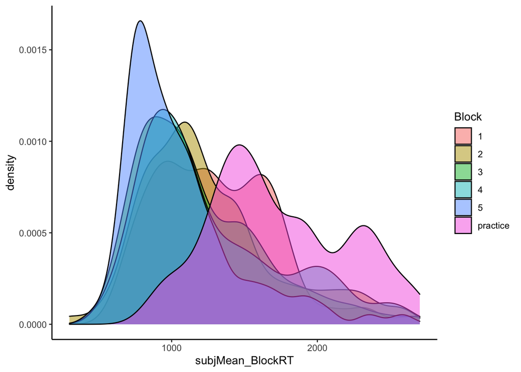

### Exclusion by trial with extreme RTs

The second step of outlier removal was to exclude trials with atypical RTs. Describe your exclusion criteria by trial and do a second round of exclusion.

Exclusion criterion: Across subjects RTs that were three standard deviatiosn away (or greater than 1.5 * IQR) were excluded

Q: Did trial-wise outlier exclusion disproportionately affect any experimental Conditions?

More trials from the Mandarin-accented condition were removed than the control condition

```
## # A tibble: 2 × 2
##   Condition                        count
##   <chr>                            <int>
## 1 Control (native accent)           1692
## 2 Mandarin-accented English (same)  1740
```

```
## # A tibble: 6 × 2
##   Block    count
##   <chr>    <int>
## 1 1          576
## 2 2          600
## 3 3          588
## 4 4          588
## 5 5          594
## 6 practice   486
```

```
## # A tibble: 2 × 2
##   Condition                        count
##   <chr>                            <int>
## 1 Control (native accent)           1594
## 2 Mandarin-accented English (same)  1612
```

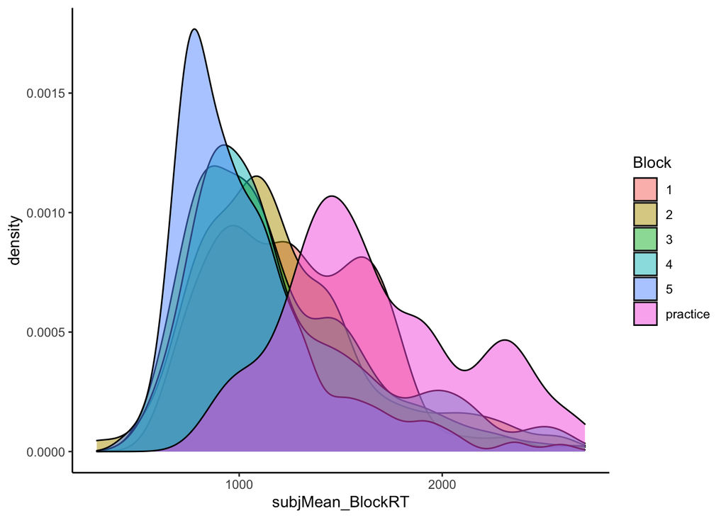

Q: Examine the mean RTs by block. Do they vary a lot before and after trial exclusion? Describe the effects.

## Examine RTs and Accuracy during practice and baseline (after exclusion steps 1 and 2)

Now that we’ve excluded extreme subject and trial outliers, we can look at the practice and baseline data to assess our high-level predictions about how participants should perform on this web-based task.

1. **One data pattern that we expect to find is that performance (both RTs and accuracy) in the practice and baseline blocks is comparable across experimental conditions.** We expect this because these blocks of the experiment were identical across conditions (i.e., native-accented stimuli presented in the clear).
   - … *if performance in the **practice block** differs substantially across conditions*, we would need to consider whether the subjects in each condition were sampled from the same underlying population (e.g., did we run all conditions at approximately the sme time of day?).
   - … *if performance in the **baseline block** differs substantially across conditions*, we would need to consider whether exposure to different types of speech during the main block of the experiment induced overall differences in task performance (in which case the baseline block doesn’t provide a reliable condition-independent “baseline” for normalization purposes).
2. **A second data pattern that we expect to find is evidence of improvement (adaptation) over the course of the task.** One way this would manifest is faster RTs and increased accuracy in the post-experiment baseline block, relative to the practice phase.

## Summary of exclusion criteria:

- Participant-level exclusions: Participants were excluded by extreme meanSubj_Block RT (i.e, values outside of 3 standard deviations or 1.5 * IQR)
- Trial-level exclusions: Excluded by extreme RTs (i.e, values outside of 3 standard deviations or 1.5 * IQR)

We applied the same exclusion criteria across all RT and error analyses.

## Normalize experimental RTs relative to baseline

Now that we’ve completed all trial-wise RT exclusions, we can calculate *normalized* RTs that take into account each subject’s baseline speed on this task. For this procedure, we adjust the RTs on each trial by subtracting out the corresponding subject’s mean RT during the baseline phase. We refer to the resulting measure as *adjusted RTs*.

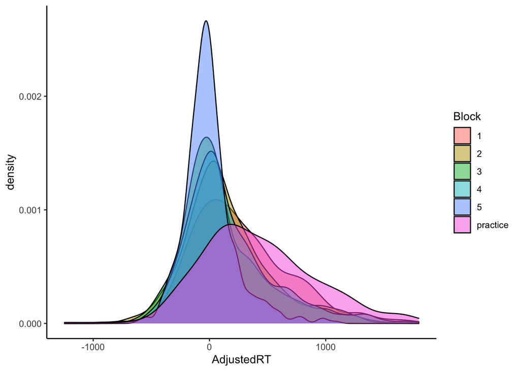

```r
# calculate each subject's mean Baseline RT
# and subtract that value from experimental RTs
dat_out2 %<>%
  group_by(WorkerId) %>%
  mutate(
    # calculate subject-wise mean RTs during baseline block
    meanBaselineRT = mean(RT[PartOfExp == "baseline"]),

    # calculate normalized RTs
    AdjustedRT = RT - meanBaselineRT,

    # calculate subject-wise mean Adjusted RT across Blocks 1-4
    meanAdjustedRT = mean(AdjustedRT[PartOfExp == "main"])
  )

dat_out2 %>%
  ggplot(aes(x=AdjustedRT,fill=Block)) +
  geom_density(alpha=0.5) +
  theme_classic()
```

Now we want to check the distribution of adjuted RTs to make sure it seems reasonable, given our expectations about task performance.

Note that we expect baseline RTs to be faster on average than RTs during the experimental block, regardless of exposure condition. We expect this for two reasons. First, the baseline task occurred at the end of the experiment, after participants had adapted to the task. Second, *all* participants heard native accented speech during the baseline phase; hence, there was no need for accent adaptation during this phase.

# Modeling strategy

## Model building and assessment

RTs were analyzed using linear mixed effects regression, as implemented in the lme4 package (version 1.1-10: Bates, Maechler, Bolker, \& Walker, 2014) in R (R Core Team, 2014). Response accuracy (incorrect vs. correct response) was analyzed using mixed effects logistic regression (see Jaeger, 2008). All mixed effects models were specified with the maximal random effects structure justified by the experimental design: that is, by-subject and by-item random intercepts, by-subject random slopes for all design variables manipulated within subjects, and by-item random slopes for all design variables manipulated within items. If the definitionally maximal model failed to converge within ten thousand iterations, the model was systematically simplified in a step-wise fashion until the model converged. These steps involved removing correlations among random effects; dropping the random effects term with the least variance; and removing fixed effects that were inconsequential for the theory being tested (i.e., counterbalancing nuisance variables).

## Variable coding

Unless otherwise specified, all numeric predictors were centered and categorical predictors were coded as sum contrasts, in order to reduce collinearity among predictors.

# Experiment 1: Adaptation to Mandarin-accented English

## Participants

Examine the number of participants per condition.

```
## # A tibble: 2 × 2
##   Condition                        count
##   <fct>                            <int>
## 1 Control (native accent)             49
## 2 Mandarin-accented English (same)    51
```

## Exp1 Response Times

Visualize the changes of RTs across blocks by condition.

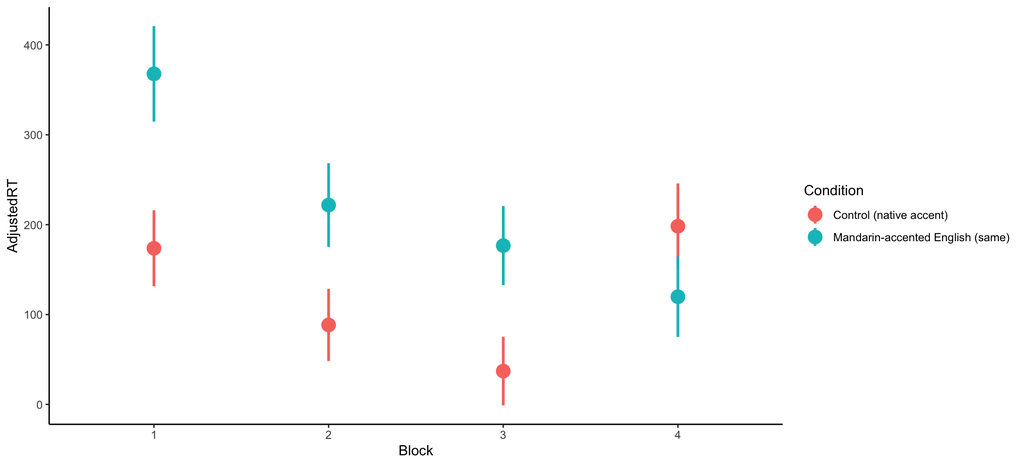

Average RTs by exposure condition in Experiment 1.

We assess the effect of exposure condition (Mandarin-accented English vs. control) on processing speed separately for RTs during the exposure phase and the test phase. To assess the *change* in RTs during the course of exposure, we split the 18-trial exposure phase into three blocks of 6 trials and use the resulting Block variable as a categorical predictor of RTs. We use linear mixed-effects models to simultaneously model subject and item random effects.

#### Exposure

A linear mixed effects model was fit to adjusted RTs for correct responses during the exposure phase.

Describe your fixed effects and random effects. Describe how each variable is coded.

```r
# Model specification:
# by-block analysis of RTs during EXPOSURE
exp1_exposure <- exp1 %>%
  filter(Phase == "Exposure phase")

m.exp <- lmer(AdjustedRT ~  Condition * as.factor(Block) + (Condition * as.factor(Block) | WorkerId) + (Condition * as.factor(Block) | Word),data=exp1_exposure)

summary(m.exp)
```

```
## Linear mixed model fit by REML ['lmerMod']
## Formula:
## AdjustedRT ~ Condition * as.factor(Block) + (Condition * as.factor(Block) |
##     WorkerId) + (Condition * as.factor(Block) | Word)
##    Data: exp1_exposure
##
## REML criterion at convergence: 24107.8
##
## Scaled residuals:
##     Min      1Q  Median      3Q     Max
## -2.3216 -0.6093 -0.1863  0.4366  4.5699
##
## Random effects:
##  Groups   Name                                Variance Std.Dev. Corr
##  WorkerId (Intercept)                          4709.8   68.63
##           ConditionAccented                   27676.8  166.36   -0.61
##           as.factor(Block)2                    9351.0   96.70   -0.52  0.26
##           as.factor(Block)3                   21117.6  145.32   -0.69  0.42
##           ConditionAccented:as.factor(Block)2 12388.1  111.30    0.46 -0.56
##           ConditionAccented:as.factor(Block)3 19361.9  139.15    0.52 -0.82
##  Word     (Intercept)                         18834.7  137.24
##           ConditionAccented                    2194.7   46.85   -0.59
##           as.factor(Block)2                    4574.1   67.63   -0.65  0.32
##           as.factor(Block)3                    9461.5   97.27   -0.70  0.66
##           ConditionAccented:as.factor(Block)2  2641.8   51.40    0.25 -0.48
##           ConditionAccented:as.factor(Block)3   731.8   27.05    0.59 -0.04
##  Residual                                     98625.3  314.05
##
##
##
##
##   0.96
##  -0.64 -0.67
##  -0.41 -0.48  0.90
##
##
##
##   0.88
##  -0.76 -0.73
##  -0.90 -0.75  0.44
##
## Number of obs: 1664, groups:  WorkerId, 99; Word, 24
##
## Fixed effects:
##                                     Estimate Std. Error t value
## (Intercept)                           282.43      36.13   7.816
## ConditionAccented                    -101.63      24.74  -4.109
## as.factor(Block)2                    -121.58      27.94  -4.352
## as.factor(Block)3                    -172.48      34.28  -5.032
## ConditionAccented:as.factor(Block)2    28.94      26.45   1.094
## ConditionAccented:as.factor(Block)3    31.59      28.47   1.110
##
## Correlation of Fixed Effects:
##             (Intr) CndtnA a.(B)2 a.(B)3 CA:.(B)2
## CndtnAccntd -0.340
## as.fctr(B)2 -0.581  0.185
## as.fctr(B)3 -0.683  0.334  0.743
## CndtA:.(B)2  0.166 -0.585 -0.347 -0.355
## CndtA:.(B)3  0.243 -0.648 -0.299 -0.281  0.657
## optimizer (nloptwrap) convergence code: 0 (OK)
## boundary (singular) fit: see help('isSingular')
```

#### Test

```r
# Model specification:
# by-block analysis of RTs during TEST
exp1_test <- exp1 %>%
  filter(Phase == "Test phase")

m.test <- lmer(AdjustedRT ~ Condition +  (Condition | WorkerId) + (Condition | Word),data=exp1_test)
summary(m.test)
```

```
## Linear mixed model fit by REML ['lmerMod']
## Formula: AdjustedRT ~ Condition + (Condition | WorkerId) + (Condition |
##     Word)
##    Data: exp1_test
##
## REML criterion at convergence: 8012.4
##
## Scaled residuals:
##     Min      1Q  Median      3Q     Max
## -3.2990 -0.5863 -0.1833  0.3748  4.0848
##
## Random effects:
##  Groups   Name              Variance Std.Dev. Corr
##  WorkerId (Intercept)        23632.2 153.73
##           ConditionAccented   3182.0  56.41   0.25
##  Word     (Intercept)        15626.3 125.01
##           ConditionAccented    793.2  28.16   -1.00
##  Residual                   109617.5 331.09
## Number of obs: 548, groups:  WorkerId, 97; Word, 24
##
## Fixed effects:
##                   Estimate Std. Error t value
## (Intercept)         163.12      33.66   4.846
## ConditionAccented    38.70      22.63   1.710
##
## Correlation of Fixed Effects:
##             (Intr)
## CndtnAccntd -0.123
## optimizer (nloptwrap) convergence code: 0 (OK)
## boundary (singular) fit: see help('isSingular')
```